# p8105_hw6_sk5855

Shiyu KANG

2026-11-24

## Problem 1

```r
library(tidyverse)
homicide_df = read_csv("homicide-data.csv",
                       na = c("","NA","Unknown")) |>
  mutate(
    city_state = str_c(city, state, sep = ", "),
    resolved = as.numeric(disposition == "Closed by arrest"),
    victim_race = fct_relevel(victim_race, "White"),
    victim_sex = fct_relevel(victim_sex, "Female")
  ) |>
  filter(
     city_state != "Dallas, TX",
     city_state != "Phoenix, AZ",
     city_state != "Kansas City, MO",
     city_state != "Tulsa, AL",
     victim_race == "Black" | victim_race == "White"
  ) |>
  select(city_state, resolved, victim_age, victim_race, victim_sex)
baltimore_df =
  homicide_df |>
  filter(city_state == "Baltimore, MD")

baltimore_fit =
  glm(
    resolved ~ victim_age + victim_race + victim_sex,
    data = baltimore_df,
    family = binomial()
  )

baltimore_result =
  baltimore_fit |>
  broom::tidy() |>
  filter(term == "victim_sexMale") |>
  mutate(
    OR = exp(estimate),
    lower_ci = exp(estimate - 1.96 * std.error),
    upper_ci = exp(estimate + 1.96 * std.error)
  ) |>
  select(term, OR, lower_ci, upper_ci)

baltimore_result
```

```
## # A tibble: 1 × 4
##   term              OR lower_ci upper_ci
##   <chr>          <dbl>    <dbl>    <dbl>
## 1 victim_sexMale 0.426    0.325    0.558
```

```r
fit_city_model = function(df) {
  glm(
    resolved ~ victim_age + victim_race + victim_sex,
    data = df,
    family = binomial()
  )
}

city_nested =
  homicide_df |>
  nest(data = c(resolved, victim_age, victim_race, victim_sex))

city_nested
```

```
## # A tibble: 47 × 2
##    city_state      data
##    <chr>           <list>
##  1 Albuquerque, NM <tibble [178 × 4]>
##  2 Atlanta, GA     <tibble [945 × 4]>
##  3 Baltimore, MD   <tibble [2,753 × 4]>
##  4 Baton Rouge, LA <tibble [410 × 4]>
##  5 Birmingham, AL  <tibble [771 × 4]>
##  6 Boston, MA      <tibble [492 × 4]>
##  7 Buffalo, NY     <tibble [479 × 4]>
##  8 Charlotte, NC   <tibble [584 × 4]>
##  9 Chicago, IL     <tibble [4,507 × 4]>
## 10 Cincinnati, OH  <tibble [679 × 4]>
## # ℹ 37 more rows
```

```r
city_models =
  city_nested |>
  mutate(
    fit = map(data, fit_city_model),
    results = map(fit, broom::tidy)
  )

city_models
```

```
## # A tibble: 47 × 4
##    city_state      data                 fit    results
##    <chr>           <list>               <list> <list>
##  1 Albuquerque, NM <tibble [178 × 4]>   <glm>  <tibble [4 × 5]>
##  2 Atlanta, GA     <tibble [945 × 4]>   <glm>  <tibble [4 × 5]>
##  3 Baltimore, MD   <tibble [2,753 × 4]> <glm>  <tibble [4 × 5]>
##  4 Baton Rouge, LA <tibble [410 × 4]>   <glm>  <tibble [4 × 5]>
##  5 Birmingham, AL  <tibble [771 × 4]>   <glm>  <tibble [4 × 5]>
##  6 Boston, MA      <tibble [492 × 4]>   <glm>  <tibble [4 × 5]>
##  7 Buffalo, NY     <tibble [479 × 4]>   <glm>  <tibble [4 × 5]>
##  8 Charlotte, NC   <tibble [584 × 4]>   <glm>  <tibble [4 × 5]>
##  9 Chicago, IL     <tibble [4,507 × 4]> <glm>  <tibble [4 × 5]>
## 10 Cincinnati, OH  <tibble [679 × 4]>   <glm>  <tibble [4 × 5]>
## # ℹ 37 more rows
```

```r
city_or_df =
  city_models |>
  select(city_state, results) |>
  unnest(cols = results) |>
  filter(term == "victim_sexMale") |>
  mutate(
    OR = exp(estimate),
    lower_ci = exp(estimate - 1.96 * std.error),
    upper_ci = exp(estimate + 1.96 * std.error)
  ) |>
  select(city_state, OR, lower_ci, upper_ci)

city_or_df
```

```
## # A tibble: 47 × 4
##    city_state         OR lower_ci upper_ci
##    <chr>           <dbl>    <dbl>    <dbl>
##  1 Albuquerque, NM 1.77     0.831    3.76
##  2 Atlanta, GA     1.00     0.684    1.46
##  3 Baltimore, MD   0.426    0.325    0.558
##  4 Baton Rouge, LA 0.381    0.209    0.695
##  5 Birmingham, AL  0.870    0.574    1.32
##  6 Boston, MA      0.667    0.354    1.26
##  7 Buffalo, NY     0.521    0.290    0.935
##  8 Charlotte, NC   0.884    0.557    1.40
##  9 Chicago, IL     0.410    0.336    0.501
## 10 Cincinnati, OH  0.400    0.236    0.677
## # ℹ 37 more rows
```

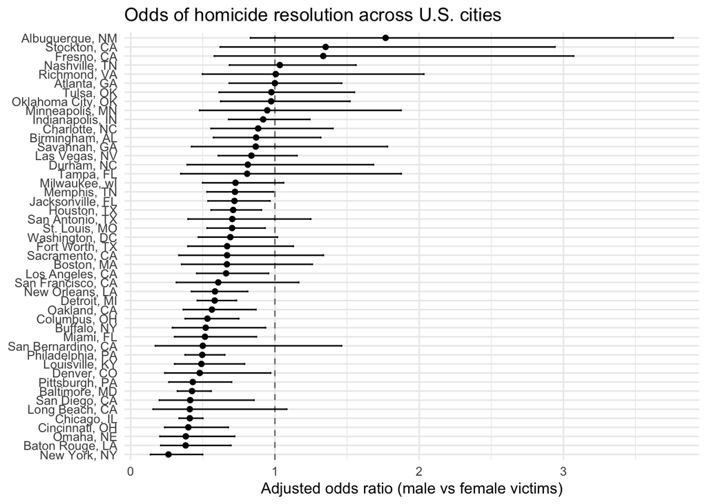

```r
#plots

city_or_df |>
  mutate(city_state = fct_reorder(city_state, OR)) |>
  ggplot(aes(x = city_state, y = OR)) +
  geom_hline(yintercept = 1, linetype = "dashed", color = "grey50") +
  geom_errorbar(aes(ymin = lower_ci, ymax = upper_ci), width = 0.2) +
  geom_point() +
  coord_flip() +
  labs(
    x = NULL,
    y = "Adjusted odds ratio (male vs female victims)",
    title = "Odds of homicide resolution across U.S. cities"
  ) +
  theme_minimal()
```

In most cities, cases involving male victims had lower estimated odds of resolution than cases involving female victims after adjustment for victim age and race. The 95% confidence intervals were entirely below 1 in cities such as Baltimore and New York. In Long Beach, the point estimate was similar to Baltimore’s, but the wider interval included 1, indicating greater uncertainty about the association.

## Problem 2

```r
library(p8105.datasets)
data("weather_df")
central_park_df = weather_df |>
  filter(name == "CentralPark_NY")

fit = lm(tmax ~ tmin + prcp, data = central_park_df)

summary(fit)
```

```
##
## Call:
## lm(formula = tmax ~ tmin + prcp, data = central_park_df)
##
## Residuals:
##     Min      1Q  Median      3Q     Max
## -6.6791 -2.0813 -0.2003  1.7064 21.2329
##
## Coefficients:
##               Estimate Std. Error t value Pr(>|t|)
## (Intercept)  7.5594644  0.1621648  46.616   <2e-16 ***
## tmin         1.0349333  0.0119109  86.890   <2e-16 ***
## prcp        -0.0015725  0.0009663  -1.627    0.104
## ---
## Signif. codes:  0 '***' 0.001 '**' 0.01 '*' 0.05 '.' 0.1 ' ' 1
##
## Residual standard error: 2.952 on 727 degrees of freedom
## Multiple R-squared:  0.9124, Adjusted R-squared:  0.9121
## F-statistic:  3784 on 2 and 727 DF,  p-value: < 2.2e-16
```

```r
broom::glance(fit) |>
  select(r.squared)
```

```
## # A tibble: 1 × 1
##   r.squared
##       <dbl>
## 1     0.912
```

```r
broom::tidy(fit) |>
  summarize(
    beta_ratio = estimate[term == "tmin"] / estimate[term == "prcp"]
  )
```

```
## # A tibble: 1 × 1
##   beta_ratio
##        <dbl>
## 1      -658.
```

```r
#bootstraping

get_weather_estimates = function(df) {
  model = lm(tmax ~ tmin + prcp, data = as.data.frame(df))

  model_stats = broom::glance(model)
  coef_table = broom::tidy(model)

  beta_tmin = coef_table$estimate[coef_table$term == "tmin"]
  beta_prcp = coef_table$estimate[coef_table$term == "prcp"]

  tibble(
    r_squared = model_stats$r.squared,
    beta_ratio = beta_tmin / beta_prcp
  )
}

set.seed(42)

boot_samples =
  central_park_df |>
  drop_na(tmax, tmin, prcp) |>
  modelr::bootstrap(n = 5000)

boot_samples
```

```
## # A tibble: 5,000 × 2
##    strap                .id
##    <list>               <chr>
##  1 <resample [730 x 6]> 0001
##  2 <resample [730 x 6]> 0002
##  3 <resample [730 x 6]> 0003
##  4 <resample [730 x 6]> 0004
##  5 <resample [730 x 6]> 0005
##  6 <resample [730 x 6]> 0006
##  7 <resample [730 x 6]> 0007
##  8 <resample [730 x 6]> 0008
##  9 <resample [730 x 6]> 0009
## 10 <resample [730 x 6]> 0010
## # ℹ 4,990 more rows
```

```r
bootstrap_results =
  boot_samples |>
  mutate(estimates = map(strap, get_weather_estimates)) |>
  select(.id, estimates) |>
  unnest(estimates)

bootstrap_results
```

```
## # A tibble: 5,000 × 3
##    .id   r_squared beta_ratio
##    <chr>     <dbl>      <dbl>
##  1 0001      0.911      -531.
##  2 0002      0.923      -529.
##  3 0003      0.911      -433.
##  4 0004      0.915      -617.
##  5 0005      0.908      -973.
##  6 0006      0.919      -459.
##  7 0007      0.906     -1025.
##  8 0008      0.921      -990.
##  9 0009      0.916      -319.
## 10 0010      0.900    -13670.
## # ℹ 4,990 more rows
```

```r
bootstrap_results |>
  summarize(
    r2_lower = quantile(r_squared, 0.025),
    r2_upper = quantile(r_squared, 0.975),
    ratio_lower = quantile(beta_ratio, 0.025),
    ratio_upper = quantile(beta_ratio, 0.975)
  )
```

```
## # A tibble: 1 × 4
##   r2_lower r2_upper ratio_lower ratio_upper
##      <dbl>    <dbl>       <dbl>       <dbl>
## 1    0.894    0.928      -5931.       4724.
```

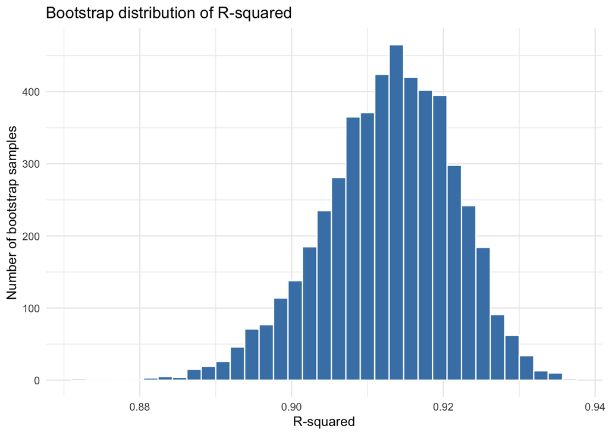

```r
bootstrap_results |>
  ggplot(aes(x = r_squared)) +
  geom_histogram(bins = 35, fill = "steelblue", color = "white") +
  labs(
    title = "Bootstrap distribution of R-squared",
    x = "R-squared",
    y = "Number of bootstrap samples"
  ) +
  theme_minimal()
```

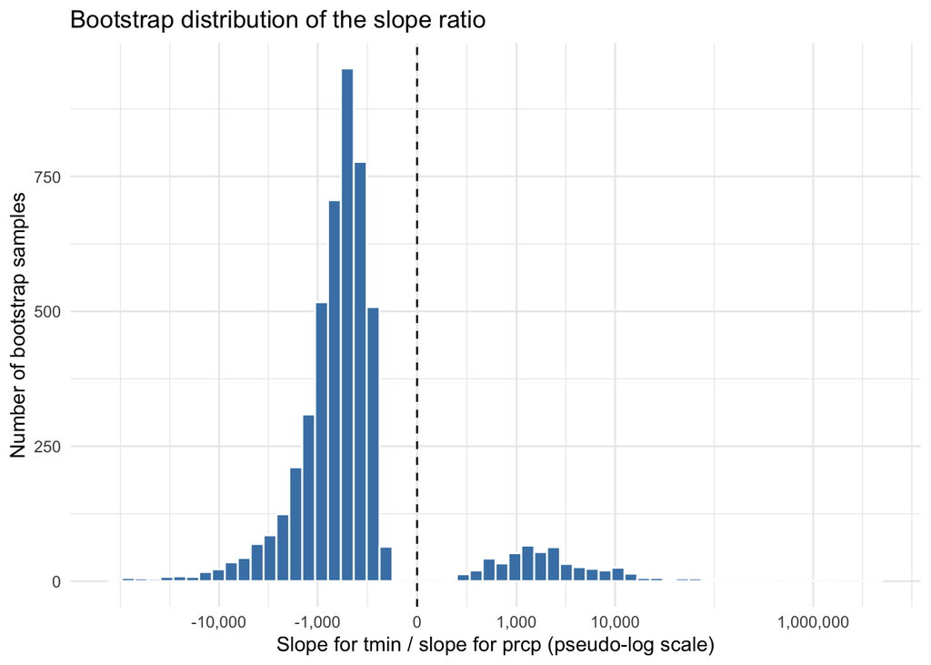

```r
bootstrap_results |>
  ggplot(aes(x = beta_ratio)) +
  geom_histogram(bins = 60, fill = "steelblue", color = "white") +
  geom_vline(xintercept = 0, linetype = "dashed") +
  scale_x_continuous(
    trans = scales::pseudo_log_trans(sigma = 100),
    breaks = c(-1e6, -1e4, -1e3, 0, 1e3, 1e4, 1e6),
    labels = scales::label_number(big.mark = ",")
  ) +
  labs(
    title = "Bootstrap distribution of the slope ratio",
    x = "Slope for tmin / slope for prcp (pseudo-log scale)",
    y = "Number of bootstrap samples"
  ) +
  theme_minimal()
```

Across 5,000 bootstrap samples, the $R^2$ estimates were concentrated around 0.91, with a 95% percentile interval of (0.894, 0.928). The slope ratio had a much wider distribution, with extreme values in both directions and a 95% percentile interval of approximately (−5,931, 4,724). This variability arises because the estimated precipitation slope is close to zero, so small changes in the denominator can produce large changes in the ratio.

## Problem 3

```r
library(modelr)

birthweight_df =
  read_csv("birthweight.csv", show_col_types = FALSE) |>
  mutate(
    babysex = factor(babysex, levels = c(1, 2), labels = c("Male", "Female")),
    malform = factor(malform, levels = c(0, 1), labels = c("Absent", "Present")),
    mrace = factor(mrace),
    frace = factor(frace)
  )

glimpse(birthweight_df)
```

```
## Rows: 4,342
## Columns: 20
## $ babysex  <fct> Female, Male, Female, Male, Female, Male, Female, Female, Mal…
## $ bhead    <dbl> 34, 34, 36, 34, 34, 33, 33, 33, 36, 33, 35, 35, 35, 36, 35, 3…
## $ blength  <dbl> 51, 48, 50, 52, 52, 52, 46, 49, 52, 50, 51, 51, 48, 53, 51, 4…
## $ bwt      <dbl> 3629, 3062, 3345, 3062, 3374, 3374, 2523, 2778, 3515, 3459, 3…
## $ delwt    <dbl> 177, 156, 148, 157, 156, 129, 126, 140, 146, 169, 130, 146, 1…
## $ fincome  <dbl> 35, 65, 85, 55, 5, 55, 96, 5, 85, 75, 55, 55, 75, 75, 65, 75,…
## $ frace    <fct> 1, 2, 1, 1, 1, 1, 2, 1, 1, 2, 1, 1, 1, 1, 1, 2, 1, 1, 1, 2, 1…
## $ gaweeks  <dbl> 39.9, 25.9, 39.9, 40.0, 41.6, 40.7, 40.3, 37.4, 40.3, 40.7, 4…
## $ malform  <fct> Absent, Absent, Absent, Absent, Absent, Absent, Absent, Absen…
## $ menarche <dbl> 13, 14, 12, 14, 13, 12, 14, 12, 11, 12, 13, 12, 13, 11, 12, 1…
## $ mheight  <dbl> 63, 65, 64, 64, 66, 66, 72, 62, 61, 64, 67, 62, 64, 68, 62, 6…
## $ momage   <dbl> 36, 25, 29, 18, 20, 23, 29, 19, 13, 19, 23, 16, 28, 23, 21, 1…
## $ mrace    <fct> 1, 2, 1, 1, 1, 1, 2, 1, 1, 2, 1, 1, 1, 1, 1, 2, 1, 1, 1, 2, 1…
## $ parity   <dbl> 3, 0, 0, 0, 0, 0, 0, 0, 0, 0, 0, 0, 0, 0, 0, 0, 0, 0, 0, 0, 0…
## $ pnumlbw  <dbl> 0, 0, 0, 0, 0, 0, 0, 0, 0, 0, 0, 0, 0, 0, 0, 0, 0, 0, 0, 0, 0…
## $ pnumsga  <dbl> 0, 0, 0, 0, 0, 0, 0, 0, 0, 0, 0, 0, 0, 0, 0, 0, 0, 0, 0, 0, 0…
## $ ppbmi    <dbl> 26.27184, 21.34485, 23.56517, 21.84508, 21.02642, 18.60030, 1…
## $ ppwt     <dbl> 148, 128, 137, 127, 130, 115, 105, 119, 105, 145, 110, 115, 1…
## $ smoken   <dbl> 0.000, 0.000, 1.000, 10.000, 1.000, 0.000, 0.000, 0.000, 0.00…
## $ wtgain   <dbl> 29, 28, 11, 30, 26, 14, 21, 21, 41, 24, 20, 31, 23, 21, 24, 2…
```

```r
colSums(is.na(birthweight_df))
```

```
##  babysex    bhead  blength      bwt    delwt  fincome    frace  gaweeks
##        0        0        0        0        0        0        0        0
##  malform menarche  mheight   momage    mrace   parity  pnumlbw  pnumsga
##        0        0        0        0        0        0        0        0
##    ppbmi     ppwt   smoken   wtgain
##        0        0        0        0
```

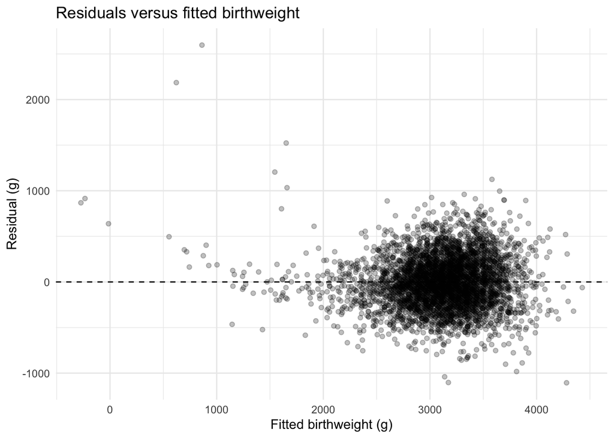

```r
proposed_fit =
  lm(bwt ~ bhead + blength + gaweeks, data = birthweight_df)

birthweight_df |>
  add_predictions(proposed_fit) |>
  add_residuals(proposed_fit) |>
  ggplot(aes(x = pred, y = resid)) +
  geom_point(alpha = 0.25) +
  geom_hline(yintercept = 0, linetype = "dashed") +
  labs(
    title = "Residuals versus fitted birthweight",
    x = "Fitted birthweight (g)",
    y = "Residual (g)"
  ) +
  theme_minimal()
```

I modeled birthweight as a function of head circumference, birth length, and gestational age. Head circumference and length describe infant size at birth, while gestational age captures the duration of fetal development. I included these predictors as additive main effects.

```r
set.seed(42)

cv_df =
  crossv_mc(birthweight_df, n = 100, test = 0.2) |>
  mutate(
    proposed = map(train, \(df)
      lm(bwt ~ bhead + blength + gaweeks, data = df)),

    main_effects = map(train, \(df)
      lm(bwt ~ blength + gaweeks, data = df)),

    interaction = map(train, \(df)
      lm(bwt ~ bhead * blength * babysex, data = df))
  ) |>
  mutate(
    rmse_proposed = map2_dbl(proposed, test, rmse),
    rmse_main_effects = map2_dbl(main_effects, test, rmse),
    rmse_interaction = map2_dbl(interaction, test, rmse)
  )

cv_results =
  cv_df |>
  select(.id, rmse_proposed, rmse_main_effects, rmse_interaction) |>
  pivot_longer(
    cols = starts_with("rmse_"),
    names_to = "model",
    names_prefix = "rmse_",
    values_to = "rmse"
  )

cv_results |>
  group_by(model) |>
  summarize(mean_rmse = mean(rmse)) |>
  arrange(mean_rmse)
```

```
## # A tibble: 3 × 2
##   model        mean_rmse
##   <chr>            <dbl>
## 1 proposed          286.
## 2 interaction       289.
## 3 main_effects      332.
```

```r
cv_results =
  cv_df |>
  select(.id, rmse_proposed, rmse_main_effects, rmse_interaction) |>
  pivot_longer(
    cols = starts_with("rmse_"),
    names_to = "model",
    names_prefix = "rmse_",
    values_to = "rmse"
  )
```

Across 100 random train–test splits, the proposed model had the lowest mean test RMSE (286g), closely followed by the interaction model (289g). The model using only birth length and gestational age had a higher mean RMSE (332g). Adding head circumference to that model reduced mean test RMSE by about 46 g.